# How Dangerous is the Windy City?

Francis Ng

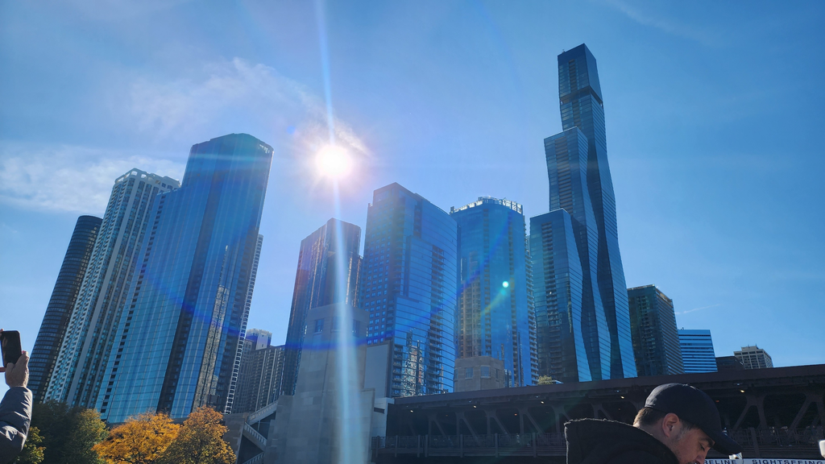

Source: Taken while I was on the famous Chicago Architecture Tour

I’m coming up on 2 years of living in Chicago, and honestly the city has grown on me quite a bit. What I heard to be a crime-ridden city full of danger turned out to be a beautiful city with fantastic people. But every time I tell someone I live here, they immediately ask if it’s safe. While I don’t think it’s what people believe it is (not even making the list for most dangerous cities in the US), I am still extremely weary. I try not to stay out late and when I do I take rideshare.

But as a statistician/scientist, I thought it’d be fun to look at the actual data of the crime in Chicago. There’s a lot to go over so this investigation will focus on things pertaining to things I’m personally worried about as someone who’s a few “opes” away from being classified as a Chicagoan (but I’ll never denounce ketchup on hotdogs)

Below are questions I will be looking to answer:

- What are the most commonly crimes in Chicago?
- When is crime most likely to happen?
- Where does most crime occur?

IMPORTANT: As I go through this analysis, let me caveat that this is merely taking a look at the data provided. It may not be entirely accurate, as this are only crimes that have been reported. This dataset may not tell the whole story, but it’s worth looking at big picture ideas to know where we can go next!

## The Dataset

For this investigation, I’ll be using data directly from the Chicago City Data Portal. I’ll primarily be using the Crimes dataset and will use the Police Beats and IUCR Codes dataset to supplement the analysis. I kept out the data loading/cleaning from the markdown file, but if you would like to see the code I used check out the R Notebook!

## Data Visualizations

### Crime Rates

Before we get started, let’s take a look into how much crime has been occurring in the city itself. Looking at the graph below, we see that there has been a steady decrease in crime since they started collecting this data in 2001. It seems there was quite a dip in 2020 before going back up in 2022. While it’s possible less crimes were being reported in 2020, it’s worth noting that this time frame, as most people could guess, was most likely due to the lockdown during COVID.

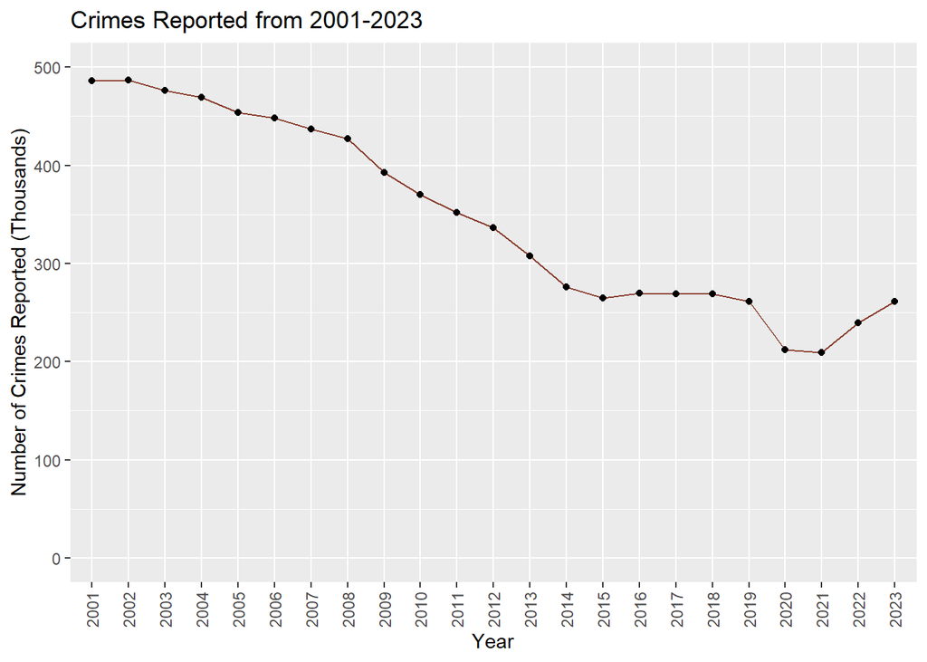

### Types of Crime in Chicago

What types of crimes are most common in Chicago? There are multiple different categories that crimes can be classified as under, with the following 10 being the most frequently reported.

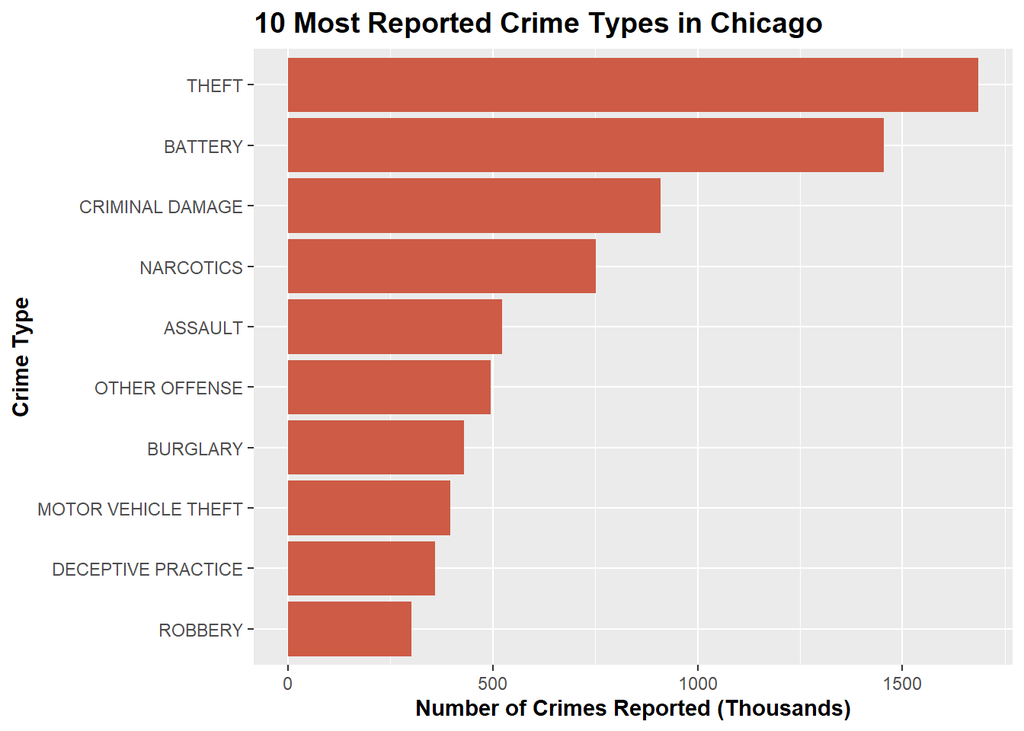

We see that it’s primarily “Theft” that seem to be reported, followed by Battery, then the rest have around half the reports. Out of the list, the items that concern me most are “Battery” and “Assault”. While things such as “Robbery” and “Homicide” (not on the top 10) do concern me, they worry me slightly less than Battery/Assault, or they don’t occur enough for me to be concerned.

But for anyone who is concerned about First Degree murder (such as me as I’m reviewing my analysis), below is a graph of the frequency of Homicides each year. While averaging around 700 homicides the past 5 years isn’t exactly a statistic most people want to hear, considering the population is 2.7 million, it’s quite unlikely to be the victim of a homicide.

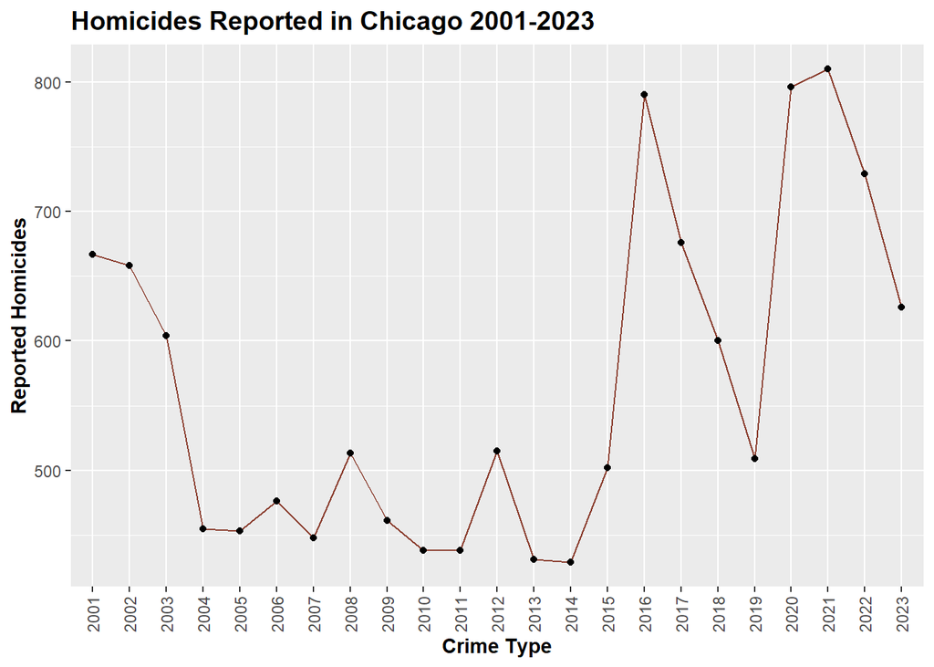

Returning to big picture, there seems to be a large amount of Battery and Assault crimes reported, which I’m concerned about. In the analysis which follows, I will sometimes be filtering on these categories. If you’re curious about the frequency of other crimes, I’ve included the full table.

|  | Crime_Type | Count |
| --- | --- | --- |
| 1 | ARSON | 13632 |
| 2 | ASSAULT | 523701 |
| 3 | BATTERY | 1455061 |
| 4 | BURGLARY | 429714 |
| 5 | CONCEALED CARRY LICENSE VIOLATION | 1224 |
| 6 | CRIM SEXUAL ASSAULT | 27525 |
| 7 | CRIMINAL DAMAGE | 908973 |
| 8 | CRIMINAL SEXUAL ASSAULT | 8089 |
| 9 | CRIMINAL TRESPASS | 217582 |
| 10 | DECEPTIVE PRACTICE | 358245 |

[output cut: 26 more lines]

If you’re interested in what the different classications of Battery/Assault, I’ve included another table below.

|  | IUCR | PRIMARY.DESCRIPTION | SECONDARY.DESCRIPTION | n |
| --- | --- | --- | --- | --- |
| 1 | 0486 | BATTERY | DOMESTIC BATTERY SIMPLE | 622865 |
| 2 | 0460 | BATTERY | SIMPLE | 572996 |
| 3 | 0560 | ASSAULT | SIMPLE | 358110 |
| 4 | 0430 | BATTERY | AGGRAVATED - OTHER DANGEROUS WEAPON | 76931 |
| 5 | 051A | ASSAULT | AGGRAVATED - HANDGUN | 66594 |
| 6 | 041A | BATTERY | AGGRAVATED - HANDGUN | 47149 |
| 7 | 0520 | ASSAULT | AGGRAVATED - KNIFE / CUTTING INSTRUMENT | 37119 |
| 8 | 0420 | BATTERY | AGGRAVATED - KNIFE / CUTTING INSTRUMENT | 31034 |
| 9 | 0530 | ASSAULT | AGGRAVATED - OTHER DANGEROUS WEAPON | 30169 |
| 10 | 0497 | BATTERY | AGGRAVATED DOMESTIC BATTERY - OTHER DANGEROUS WEAPON | 23746 |

[output cut: 35 more lines]

### When does crime happen in Chicago?

As mentioned above, my concern about the crime in Chicago is at its highest when it gets dark. I took a look at the number of crimes that occurred during each hour of the day to see which hours of the day the most crime took place.

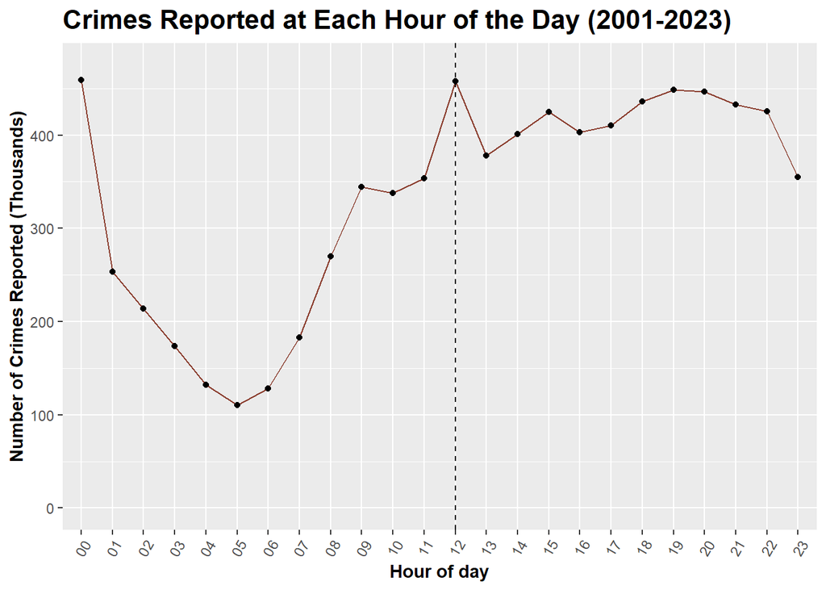

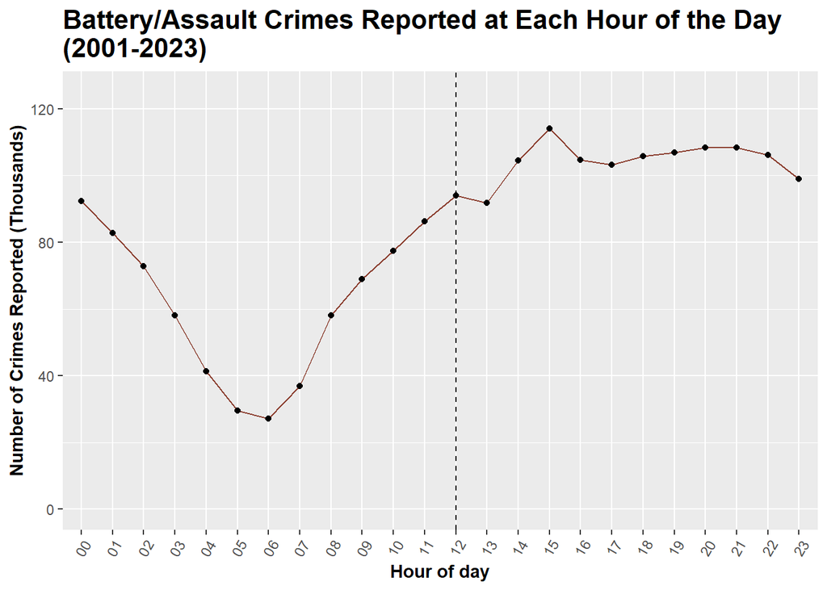

Compared to our previous graph, it appears relatively the same with less outliers present. We see a drop in reported crimes from midnight to about 6-7am when the reports start increasing. One thing I was curious about was whether the season of the year changed anything. Numerous factors change with the seasons such as temperature, and daylight hours. To investigate this I took the graph above and looked at what the numbers were month to month.

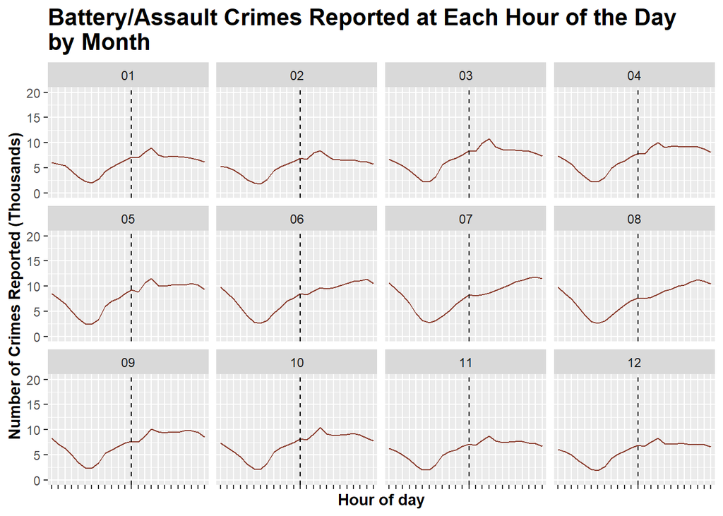

As you see here, the general shape of the graph appears to be the same.

From only an eye test, it appears that crime reports seems to follow the same trend. Further time-series analysis could be done, but perhaps for a future project. While it does seem that wandering the streets at 5am appears to be the safest time, I’m not exactly sure if I would be willing or awake enough to go exploring then. As with the rest of the analysis, we must also consider that because these are only from reports, people may be less willing to report a crime if it happens late at night.

### Where does crime happen?

Although I now know to go out at 5AM if I want to explore, some locations are still more dangerous than others. In this part of the analysis, I’ll be looking at the location description of where these reported crimes occurred, along with which parts of Chicago seem to have the most crime.

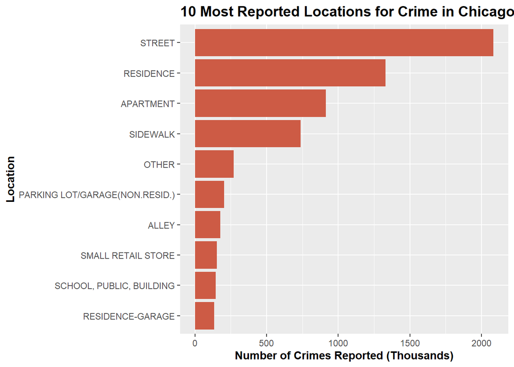

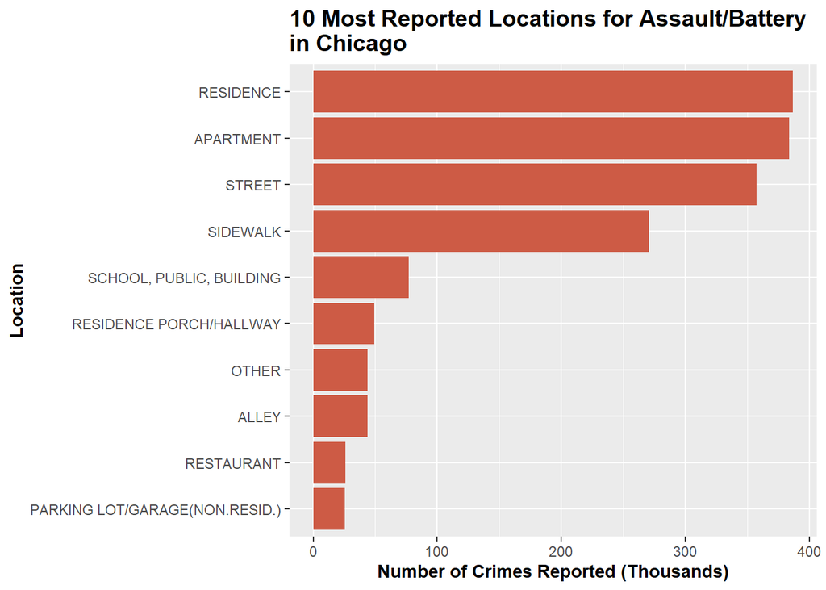

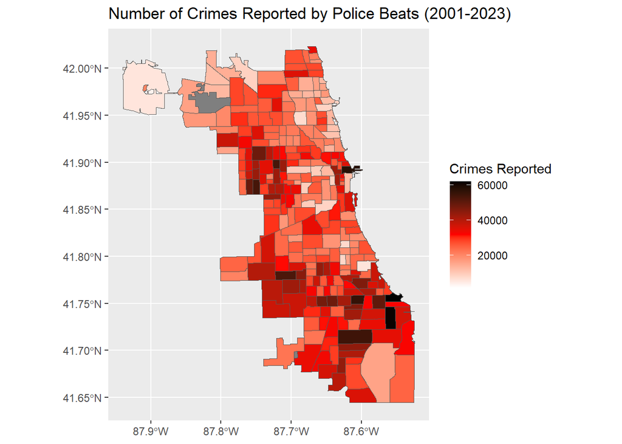

If you’re looking at the gray areas, those are beat number “3100”. While this graph gives us a good idea of where crimes are usually reported, let’s take a look at only assault/battery crimes.

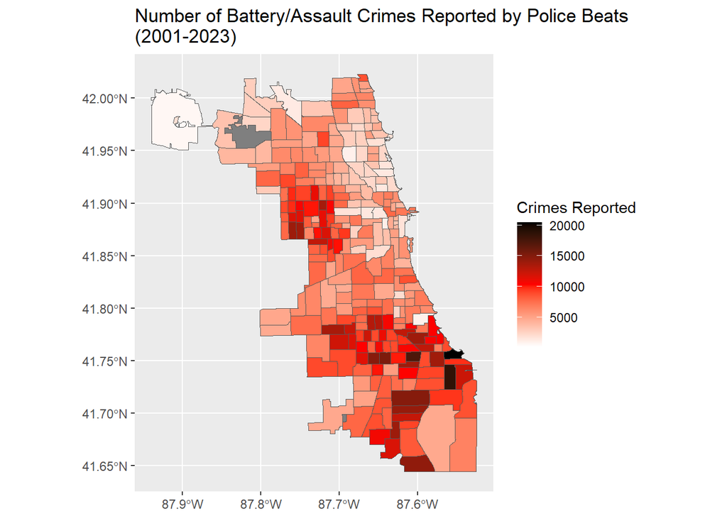

While this map does look like a more diluted version of the full one, I immediately noticed one outlier was that Police Beat right next to (41.90N, 87.6W). That area is the Magnificent Mile, a very famous shopping area in Chicago, so it would make sense that more thefts happen there than anything. There appears to be other areas that are different in what we see from our Assault/Battery graph, but that’s outside of the scope of this investigation.

If you don’t live in Chicago and want to visit, what does this mean? Well for starters, that white area in top left is where O’Hare airport is, so you should be safe upon arriving. Ultimately, it looks like as long as you don’t go to the West/South neighborhoods, you’ll be less likely to encounter Assault/Battery. This is great, as the most famous spots in the city seem to have less reported crime. It should be noted that this graph does not consider population density, which could play a part in how likely it is that crime could occur per person you meet.

What does this mean for me? Aside from the Mag Mile, it appears that most crime has been report in the South and some West areas, while the Northern neighborhoods have low reported numbers. This aligns with the general sentiment I’ve picked up while living here. I will not disclose more about my direct lessons learned, as I would prefer not to share where I currently reside.

## Conclusion

This was my first analysis in a long time, please let me know if you have any feedback either through email francisng370@gmail.com. I hope this is the first of many projects I’ll be looking at investigating this data, I already have an idea for a part 2!